# Myeloid MAGIC visualization

Marc Elosua-Bayes

febrero 10, 2022

## Introduction

In this Rmarkdown document we are going to load the MAGIC-denoised data to better visualize genes and ease with the annotation when using specific marker genes. [MAGIC](https://magic.readthedocs.io/en/stable/) was developed by Smita Krishnaswamy’s lab to try to fill in the drop out reads in the spots. `MAGIC` is a Markov Affinity-based Graph Imputation of Cells used for denoising high-dimensional data most commonly applied to single-cell RNA sequencing data. MAGIC learns the manifold data, using the resultant graph to smooth the features and restore the structure of the data based on their k-nearest neighbors.

## Libraries

```r
library(Seurat)
library(dplyr)
library(ggplot2)
library(SPATA2)
library(UCell)
library(stringr)
```

## Parameters

```r
set.seed(123)
source(here::here("misc/paths.R"))
source(here::here("utils/bin.R"))

"{myeloid}/{plt_dir}" %>%
  glue::glue() %>%
  here::here() %>%
  dir.create(path = .,
             showWarnings = FALSE,
             recursive = TRUE)

"{myeloid}/{robj_dir}" %>%
  glue::glue() %>%
  here::here() %>%
  dir.create(path = .,
             showWarnings = FALSE,
             recursive = TRUE)
```

## Load data

The data used in this Rmarkdown document comes from **03-clustering_integration.Rmd** where the data was integrated.

```r
merged_se <- "{anot}/{robj_dir}/integrated_spatial_annot.rds" %>%
  glue::glue() %>%
  here::here() %>%
  readRDS(file = .)
```

Load MAGIC data from the script *MAGIC_denoising-myeloid.Rmd*

```r
magic_df <- "{myeloid}/{robj_dir}/MAGIC-mtrx.rds" %>%
  glue::glue() %>%
  here::here() %>%
  readRDS(file = .)

# create a new assay to store ADT information
magic_assay <- CreateAssayObject(counts = as.matrix(magic_df))

# Subset merged_se to those barcodes used
merged_se <- merged_se[, colnames(magic_df)]

# add this assay to the previously created Seurat object
merged_se[["MAGIC_Spatial"]] <- magic_assay
```

## Analysis

A Spatially Resolved Dark- versus Light-Zone Microenvironment Signature Subdivides Germinal Center-Related Aggressive B Cell Lymphomas - **Dark Zone**: OAZ1, AICDA, H3, MKI67, POLH - **Light Zone**: LAG3, ITGB8, PDCD1, TIGIT, BCL2, PECAM1, LY6E, B7-H3 (CD276), HLA-DRB1, PSMB10, TNF, ARG1, HLA-E, STAT1

```r
"{myeloid}/gene_dict_myeloid.R" %>%
  glue::glue() %>%
  here::here() %>%
  source(file = .)
gene_vec <- rownames(magic_df)
```

### Marker gene location

Look at the location where the genes of interest are expressed

```r
Seurat::DefaultAssay(merged_se) <- "MAGIC_Spatial"

# Iterate over each image
lapply(id_sp_df$gem_id, function(i) {
  print(i)

  gene_plt <- Seurat::SpatialFeaturePlot(
    object = merged_se,
    features = myeloid_vec,
    alpha = c(0, 1),
    ncol = 7,
    images = i)

  # Save plot
  "{myeloid}/{plt_dir}/magic_myeloid_markers_{i}.pdf" %>%
    glue::glue() %>%
    here::here() %>%
    cowplot::save_plot(
      filename = .,
      plot = gene_plt,
      base_height = 45,
      base_width = 40)
})
```

```
## [1] "tarwe1_xott6q"
```

```
## [1] "c28w2r_7jne4i"
```

```
## [1] "esvq52_nluss5"
```

```
## [1] "p7hv1g_tjgmyj"
```

```
## [1] "gcyl7c_cec61b"
```

```
## [1] "zrt7gl_lhyyar"
```

```
## [1] "qvwc8t_2vsr67"
```

```
## [1] "exvyh1_66caqq"
```

```
## [[1]]
## [1] "/scratch/devel/melosua/phd/projects/BCLLatlas/tonsil_atlas/spatial_transcriptomics/myeloid_integration/2020-09-22/plots_2020-09-22/magic_myeloid_markers_tarwe1_xott6q.pdf"
##
## [[2]]
## [1] "/scratch/devel/melosua/phd/projects/BCLLatlas/tonsil_atlas/spatial_transcriptomics/myeloid_integration/2020-09-22/plots_2020-09-22/magic_myeloid_markers_c28w2r_7jne4i.pdf"
##
## [[3]]
## [1] "/scratch/devel/melosua/phd/projects/BCLLatlas/tonsil_atlas/spatial_transcriptomics/myeloid_integration/2020-09-22/plots_2020-09-22/magic_myeloid_markers_esvq52_nluss5.pdf"
##
## [[4]]
## [1] "/scratch/devel/melosua/phd/projects/BCLLatlas/tonsil_atlas/spatial_transcriptomics/myeloid_integration/2020-09-22/plots_2020-09-22/magic_myeloid_markers_p7hv1g_tjgmyj.pdf"
##
## [[5]]
## [1] "/scratch/devel/melosua/phd/projects/BCLLatlas/tonsil_atlas/spatial_transcriptomics/myeloid_integration/2020-09-22/plots_2020-09-22/magic_myeloid_markers_gcyl7c_cec61b.pdf"
##
## [[6]]
## [1] "/scratch/devel/melosua/phd/projects/BCLLatlas/tonsil_atlas/spatial_transcriptomics/myeloid_integration/2020-09-22/plots_2020-09-22/magic_myeloid_markers_zrt7gl_lhyyar.pdf"
##
## [[7]]
## [1] "/scratch/devel/melosua/phd/projects/BCLLatlas/tonsil_atlas/spatial_transcriptomics/myeloid_integration/2020-09-22/plots_2020-09-22/magic_myeloid_markers_qvwc8t_2vsr67.pdf"
##
## [[8]]
## [1] "/scratch/devel/melosua/phd/projects/BCLLatlas/tonsil_atlas/spatial_transcriptomics/myeloid_integration/2020-09-22/plots_2020-09-22/magic_myeloid_markers_exvyh1_66caqq.pdf"
```

Now with the log-norm expression

```r
Seurat::DefaultAssay(merged_se) <- "Spatial"

lapply(id_sp_df$gem_id, function(i) {
  # Iterate over each image
  gene_plt <- Seurat::SpatialFeaturePlot(
    object = merged_se,
    features = myeloid_vec,
    alpha = c(0, 1),
    ncol = 7,
    images = i)

  "{myeloid}/{plt_dir}/lognorm_myeloid_markers_{i}.pdf" %>%
    glue::glue() %>%
    here::here() %>%
    cowplot::save_plot(
      filename = .,
      plot = gene_plt,
      base_height = 45,
      base_width = 40)
})
```

```
## [[1]]
## [1] "/scratch/devel/melosua/phd/projects/BCLLatlas/tonsil_atlas/spatial_transcriptomics/myeloid_integration/2020-09-22/plots_2020-09-22/lognorm_myeloid_markers_tarwe1_xott6q.pdf"
##
## [[2]]
## [1] "/scratch/devel/melosua/phd/projects/BCLLatlas/tonsil_atlas/spatial_transcriptomics/myeloid_integration/2020-09-22/plots_2020-09-22/lognorm_myeloid_markers_c28w2r_7jne4i.pdf"
##
## [[3]]
## [1] "/scratch/devel/melosua/phd/projects/BCLLatlas/tonsil_atlas/spatial_transcriptomics/myeloid_integration/2020-09-22/plots_2020-09-22/lognorm_myeloid_markers_esvq52_nluss5.pdf"
##
## [[4]]
## [1] "/scratch/devel/melosua/phd/projects/BCLLatlas/tonsil_atlas/spatial_transcriptomics/myeloid_integration/2020-09-22/plots_2020-09-22/lognorm_myeloid_markers_p7hv1g_tjgmyj.pdf"
##
## [[5]]
## [1] "/scratch/devel/melosua/phd/projects/BCLLatlas/tonsil_atlas/spatial_transcriptomics/myeloid_integration/2020-09-22/plots_2020-09-22/lognorm_myeloid_markers_gcyl7c_cec61b.pdf"
##
## [[6]]
## [1] "/scratch/devel/melosua/phd/projects/BCLLatlas/tonsil_atlas/spatial_transcriptomics/myeloid_integration/2020-09-22/plots_2020-09-22/lognorm_myeloid_markers_zrt7gl_lhyyar.pdf"
##
## [[7]]
## [1] "/scratch/devel/melosua/phd/projects/BCLLatlas/tonsil_atlas/spatial_transcriptomics/myeloid_integration/2020-09-22/plots_2020-09-22/lognorm_myeloid_markers_qvwc8t_2vsr67.pdf"
##
## [[8]]
## [1] "/scratch/devel/melosua/phd/projects/BCLLatlas/tonsil_atlas/spatial_transcriptomics/myeloid_integration/2020-09-22/plots_2020-09-22/lognorm_myeloid_markers_exvyh1_66caqq.pdf"
```

```r
se_sub <- subset(merged_se, subset = gem_id == "esvq52_nluss5")
se_sub
```

```
## An object of class Seurat
## 26997 features across 3079 samples within 2 assays
## Active assay: Spatial (26846 features, 2000 variable features)
##  1 other assay present: MAGIC_Spatial
##  3 dimensional reductions calculated: pca, umap, harmony
```

```r
se_sub@images <- se_sub@images[Seurat::Images(se_sub) == "esvq52_nluss5"]
```

### Correlation matrix

Since we are working with sample esvq52_nluss5 in this example we will limit the correlation plot to this slide.

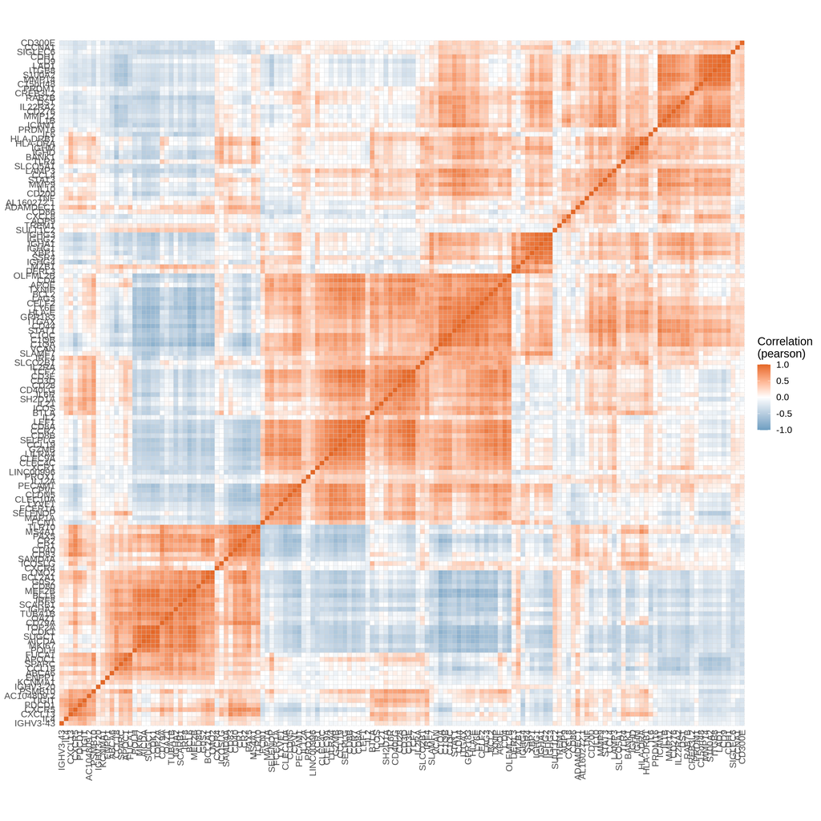

```r
(cor_mtrx <- SCrafty::correlation_heatmap(
  se = se_sub,
  genes = gene_vec,
  assay = "MAGIC_Spatial",
  slot = "data"))
```

```r
"{myeloid}/{plt_dir}/magic_cor-mtrx_markers.pdf" %>%
  glue::glue() %>%
  here::here() %>%
  cowplot::save_plot(
    filename = .,
    plot = cor_mtrx,
    base_height = 15,
    base_width = 15)

  # Correlation with lognorm expression
cor_log <- SCrafty::correlation_heatmap(
  se = se_sub,
  genes = gene_vec,
  assay = "Spatial",
  slot = "data")

"{myeloid}/{plt_dir}/lognorm_cor-mtrx_markers.pdf" %>%
  glue::glue() %>%
  here::here() %>%
  cowplot::save_plot(
    filename = .,
    plot = cor_log,
    base_height = 9,
    base_width = 10)
```

Look at them side by side

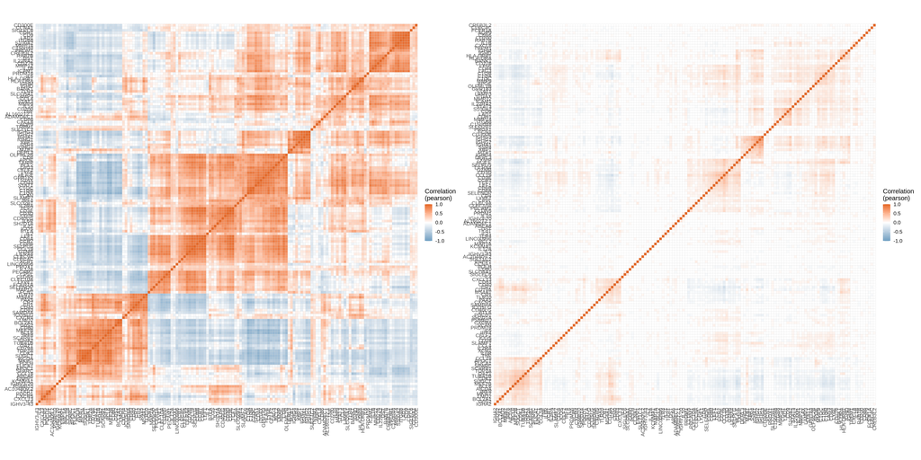

```r
cor_mtrx + cor_log
```